### Diskrečių struktūrų statistinė analizė

# Laboratoriniai darbai

#### Elijas Dapšauskas

Paruošiama darbo aplinka. Sukuriamos pagalbinės funkcijos.

```r
# Lietuviu kalbos palaikymas
l = Sys.setlocale(locale="lithuanian")
```

```r
library(ggplot2) # Grafikai
library(zeallot) # Operatorius %<-%
# Grafiko dydis
options(repr.plot.width=10, repr.plot.height=3)
# Vektoriaus išskleidimas į diagonalią matricą
diagonali_matrica = function(vec) diag(c(matrix(vec, 1)))
# Duomenų normalizavimas
Normalizatorius = function(X) {
    M = apply(X, 2, mean)
    S = apply(X, 2, sd)
    list(normalizuoti=function(x) (x - M) / S,
         denormalizuoti=function(x) x * S + M)
}
```

# 1 lab. darbas | Tikslusis Fišerio testas

> Dviejų požymių nepriklausomumo hipotezei patikrinti paprastai naudojamas chi-kvadrat testas. Žinoma, kad kriterijaus statistikos pasiskirstymas aproksimuojamas chi-kvadrat pasiskirstymu, todėl šiuo atveju p-reikšmės yra apytikslės.

> Jeigu stebimi požymiai yra dvireikšmiai ir iš jų sudaroma 2 × 2 dydžio dažnių lentelė, tai nepriklausomumo hipotezei patikrinti galima naudoti tikslųjį Fišerio testą. R šiam tikslui turi funkciją fisher.test. Šiuo atveju p-reikšmė apskaičiuojama tiksliai.

> UŽDUOTIS. Parašyti R funkciją, kuri hipotezę apie dviejų požymių nepriklausomumą 2 × 2 dydžio lentelėje patikrintų naudojant tikslųjį Fišerio testą.

> Funkcijos argumentai: arba dažnių lentelė, arba kintamieji, iš kurios dažnių lentelė sudaroma funkcijos viduje. Jeigu reikia, galima perduoti reikšmingumo lygmens α reikšmę.

> Funkcija turi grąžinti p-reikšmę. Taip pat gali būti išvedama papildoma informacija, pavyzdžių sprendimas apie hipotezės priėmimą arba atmetimą, jeigu funkcijai nurodomas reikšmingumo lygmuo α.

> Funkcijos veikimą galima išbandyti su duomenimis iš lentelės ksimpah.csv.

Įvedami duomenys pagal knygos `3.5.14` lentelę. `a` žymima pirmoji gardelė.

```r
a = 3
b = 16
c = 2
d = 21

# Si funkcija leidzia lengvai keisti lenteles gardeles
# kaskart nustacius nauja gardele a.
# Kitos gardeles keiciamos taip, kad nepakistu
# eiluciu ir stulpeliu sumos.
DazniuLentele =
function(A, B, C, D)
function(a = A) rbind(
    c(    a,     A+B - a ),
    c( A+C - a, -A+D + a ))

dazniu_lentele = DazniuLentele(A=a, B=b, C=c, D=d)
dazniu_lentele()
```

A matrix: 2 × 2 of type dbl

| 3 | 16 |
| --- | --- |
| 2 | 21 |

Pateiksime keletą pavyzdžių, kaip galime keisti gardelę a. Pavyzdžiui, gauname duomenis pagal knygos `3.5.15` lentelę.

```r
dazniu_lentele(a=4)
```

A matrix: 2 × 2 of type dbl

| 4 | 15 |
| --- | --- |
| 1 | 22 |

Duomenys pagal knygos `3.5.16` lentelę.

```r
dazniu_lentele(a=5)
```

A matrix: 2 × 2 of type dbl

| 5 | 14 |
| --- | --- |
| 0 | 23 |

Įvardijama hipotezė.

$$ \begin{cases} H_0 : p_{ij}=p_ip_j, \quad\text{su visais} \space i =1,2, \space j=1,2; \\ H_1 : p_{ij}\neq p_ip_j, \quad\text{bent vienai porai} \space (i,j). \end{cases} $$

Apibrėžiama hipergeometrinio skirstinio tikimybė `P` duotai `2 x 2` dažnių lentelei. Čia $n = a + b+c+d$.

$$ P(a,b,c,d) = \frac{(a+b)! \space(c+d)! \space(a+c)! \space(b+d)!}{a!\space b!\space c!\space d!\space n!} $$

```r
f = factorial
P = function(dazniu_lentele) {
    c(a, b, c, d) %<-% dazniu_lentele
    n = a + b + c + d
    prod(f(c(a+b, c+d, a+c, b+d))) / prod(f(c(a,b,c,d,n)))
}
```

Hipotezei $H_0$ patikrinti reikia su `P` formule apskaičiuoti tikimybes dažnių lentelei ir visoms galimoms lentelėms kurių gardelės dažnis yra mažesnis už $a$. Tuomet visas gautas tikimybes sudėti.

```r
(a = dazniu_lentele()[1, 1])
```

3

```r
(P_sum =
    P(dazniu_lentele(a=3)) +
    P(dazniu_lentele(a=2)) +
    P(dazniu_lentele(a=1)) +
    P(dazniu_lentele(a=0))
)
```

0.881533101045296

Pasitikriname gautą rezultatą su `fisher.test`.

```r
fisher.test(dazniu_lentele(), alternative="less")$p.value
```

0.881533101045296

Jeigu sudėjus gautas tikimybes suma neviršija pusės pasirinkto reikšmingumo lygmens, t.y. $\alpha\space/\space2$, nulinę hipotezę $H_0$ reikia atmesti.

```r
alpha = 0.05
```

```r
cat(ifelse(
    P_sum <= alpha / 2,
    "Hipoteze H0 reikia atmesti",
    "Hipotezes H0 atmesti negalime"
))
```

```
Hipotezes H0 atmesti negalime
```

Jeigu suma viršija $\alpha\space/\space2$, tai reikia skaičiuoti `P` tikimybes turimai dažnių lentelei ir visoms galimoms dažnių lentelėms kurių gardelės dažnis yra didesnis už $a$

```r
(a = dazniu_lentele()[1, 1])
```

3

Randame, kokia yra didžiausia galima gardelės $a$ reikšmė. Norint nepakeisti $a$ gardelės eilutės sumos ir $a$ gardelės stupelio sumos, didžiausia galima gardelės reikšmė bus lygi atitinkamai eilutės ar stulpelio sumai.

```r
dazniu_lentele()
```

A matrix: 2 × 2 of type dbl

| 3 | 16 |
| --- | --- |
| 2 | 21 |

```r
(a_max = min(a + b, a + c))
```

5

Randame, kokioms gardelėms $a$ skaičiuosime tikimybę `P`

```r
a:a_max
```

1. 3

2. 4

3. 5

Hipotezei $H_0$ patikrinti reikia su `P` formule apskaičiuoti tikimybes dažnių lentelei ir visoms galimoms lentelėms kurių gardelės dažnis yra didesnis už $a$ bei visas šias tikimybes sudėti.

```r
P_sum = 0
for ( A in a:a_max ) {
    P_sum = P_sum + P(dazniu_lentele(a=A))
}
P_sum
```

0.406660412757974

Pasitikriname gautą rezultatą su `fisher.test`.

```r
fisher.test(dazniu_lentele(), alternative="greater")$p.value
```

0.406660412757974

Jeigu sudėjus gautas tikimybes suma neviršija pusės pasirinkto reikšmingumo lygmens, t.y. $\alpha\space/\space2$, nulinę hipotezę $H_0$ reikia atmesti.

```r
cat(ifelse(
    P_sum <= alpha / 2,
    "Hipoteze H0 reikia atmesti",
    "Hipotezes H0 atmesti negalime"
))
```

```
Hipotezes H0 atmesti negalime
```

Išvada: Turimai dažnių lentelei

```r
dazniu_lentele()
```

A matrix: 2 × 2 of type dbl

| 3 | 16 |
| --- | --- |
| 2 | 21 |

hipotezės $H_0 : p_{ij}=p_ip_j$ atmesti negalime, todėl ji yra priimama. Pagal tikslų Fišerio kriterijų, požymiai yra nepriklausomi.

Implementuosime pilną R funkciją. Grąžinsime dvi p reikšmes, nes tikrinsime testą iš abiejų pusių.

Išreikšime hipergeometrinio skirstinio tikimybę $P$ per binominius koeficientus, nes kai $P$ išreikšta per faktorialus, tuomet tarpiniuose skaičiavimuose gaunami labai dideli skaičiai, dėl kurių R programa grąžina `Inf` reikšmes.

$$ P(a,b,c,d) = \frac{(a+b)! \space(c+d)! \space(a+c)! \space(b+d)!}{a!\space b!\space c!\space d!\space n!} = \\ = \frac{\binom{a\space+\space b}{a}\binom{c\space+\space d}{c}}{\binom{n}{a\space+\space c}} $$

```r
# Hipergeometrinio skirstinio tikimybe
P = function(a,b,c,d)
    choose(a+b, a) *
    choose(c+d, c) /
    choose(a+b+c+d, a+c)

# Implementuota funkcija grazinanti p reiksmes
tikslusis_fisher_testas = function(a, b, c, d, alpha=NULL) {
    p1 = sum(sapply(0:a, function(A)
        P(a = A,        b =  a+b - A,
          c = a+c - A,  d = -a+d + A)
    ))

    a_max = min(a+b, a+c)
    p2 = sum(sapply(a:a_max, function(A)
        P(a = A,        b =  a+b - A,
          c = a+c - A,  d = -a+d + A)
    ))

    if (!is.null(alpha))
        cat(ifelse(
            p1 <= alpha / 2 || p2 <= alpha / 2,
            "H0 yra atmetama. Požymiai yra priklausomi.",
            "H0 yra priimama. Požymiai yra nepriklausomi."
        ))

    data.frame(p1, p2)
}

# Funkcija isbandoma
tikslusis_fisher_testas(
    a=3, b=16,
    c=2, d=21,
    alpha=0.05
)
```

```
H0 yra priimama. Požymiai yra nepriklausomi.
```

A data.frame: 1 × 2

| p1 <dbl> | p2 <dbl> |
| --- | --- |
| 0.8815331 | 0.4066604 |

Pasitikriname su `fisher.test`.

```r
data.frame(
    p1=fisher.test(rbind(c(3,16),c(2,21)),
                   alternative="less")$p.value,
    p2=fisher.test(rbind(c(3,16),c(2,21)),
                   alternative="greater")$p.value
)
```

A data.frame: 1 × 2

| p1 <dbl> | p2 <dbl> |
| --- | --- |
| 0.8815331 | 0.4066604 |

Išbandysime funkcijos veikimą su duomenimis iš lentelės `ksimpah.csv`.

```r
df = read.csv2('ksimpah.csv', encoding="UTF-8")
head(df)
```

A data.frame: 6 × 12

|  | Lytis <chr> | Hipertenzija <chr> | Tabakas <chr> | Alkoholis <chr> | Ūgis <dbl> | Svoris <dbl> | KMI <dbl> | Antsvoris <chr> | EQ <dbl> | EZ <dbl> | FC <dbl> | FE <dbl> |
| --- | --- | --- | --- | --- | --- | --- | --- | --- | --- | --- | --- | --- |
| 1 | Vyras | Sveikas | Nerūko | Geria | 181.0 | 77.0 | 23.50 | Ne | 519.5 | 803.0 | 1.20 | 4.62 |
| 2 | Vyras | Sveikas | Nerūko | Geria | 182.0 | 108.0 | 32.60 | Yra | 517.5 | 797.0 | 2.15 | 5.22 |
| 3 | Vyras | Serga | Nerūko | Negeria | 187.0 | 122.0 | 34.89 | Yra | 654.0 | 554.5 | 2.85 | 4.89 |
| 4 | Vyras | Sveikas | Nerūko | Geria | 178.5 | 64.0 | 20.09 | Ne | 518.5 | 727.5 | 1.40 | 4.56 |
| 5 | Moteris | Sveikas | Rūko | Geria | 170.0 | 57.5 | 19.90 | Ne | 472.5 | 662.5 | 1.80 | 4.01 |
| 6 | Vyras | Sveikas | Nerūko | Geria | 187.5 | 70.0 | 19.91 | Ne | 516.0 | 680.5 | 1.55 | 4.73 |

```r
(dazniu_lentele = table(df[c('Lytis', 'Antsvoris')]))
c(a, b, c, d) %<-% dazniu_lentele
```

```
         Antsvoris
Lytis     Yra Ne
  Moteris  10 60
  Vyras    26 57
```

```r
alpha = 0.05
tikslusis_fisher_testas(a,b,c,d,alpha)
```

```
H0 yra atmetama. Požymiai yra priklausomi.
```

A data.frame: 1 × 2

| p1 <dbl> | p2 <dbl> |
| --- | --- |
| 0.01040685 | 0.9966421 |

# 2 lab. darbas | Logistinės regresijos modelio parametrų vertinimas

> Duomenų faile ksimpah.csv yra realaus medicininio tyrimo duomenys apie paauglių susirgimą pirminę arterinę hipertenziją. Kategoriniai dvireikšmiai kintamieji:
> - Hipertenzija -- ar pacientas serga pirmine arterine hipertenzija;
> - Lytis -- paciento lytis;
> - Tabakas -- nurodo, ar pacientas rūko;
> - Alkoholis -- nurodo, ar pacientas vartoja alkoholį;
> - Antsvoris -- nurodo, ar pacientas turi antsvorį.

> Taip pat yra keletas kiekybinių kintamųjų:
> - Ūgis,
> - Svoris,
> - KMI -- kūno masės indeksas.

> Reikia pasirinkti dvireikšmį kintamąjį, kuris bus atsako kintamasis Y ir jam parinkti regresorių. Tyrime buvo tiriama hipertenzijos priklausomybė nuo kitų faktorių, pavyzdžiui, antsvorio, lyties ir pan., todėl Y gali būti Hipertenzija, o X gali būti Antsvoris. Galimi ir kiti kintamųjų variantai. Nuo to priklausys parametrų interpretacija.

> UŽDUOTIS. Reikia sudaryti logistinės regresijos modelį atsako kintamojo Y vidurkiui modeliuoti ir įvertinti jo parametrus β₀ ir β₁ Newton-Raphson metodu. Paiškinti gautų parametrų prasmę.

> PASTABA. Gauti parametrų įverčiai turi sutapti su įverčiais, gautais naudojant standartinę R funkciją glm:

> `mod <- glm(Y ~ 1 + X, data = duomenys, family = binomial("logit"))`  
> `summary(mod)`

Įkeliami duomenys.

```r
df = read.csv2('ksimpah.csv', encoding="UTF-8")
head(df)
```

A data.frame: 6 × 12

|  | Lytis <chr> | Hipertenzija <chr> | Tabakas <chr> | Alkoholis <chr> | Ūgis <dbl> | Svoris <dbl> | KMI <dbl> | Antsvoris <chr> | EQ <dbl> | EZ <dbl> | FC <dbl> | FE <dbl> |
| --- | --- | --- | --- | --- | --- | --- | --- | --- | --- | --- | --- | --- |
| 1 | Vyras | Sveikas | Nerūko | Geria | 181.0 | 77.0 | 23.50 | Ne | 519.5 | 803.0 | 1.20 | 4.62 |
| 2 | Vyras | Sveikas | Nerūko | Geria | 182.0 | 108.0 | 32.60 | Yra | 517.5 | 797.0 | 2.15 | 5.22 |
| 3 | Vyras | Serga | Nerūko | Negeria | 187.0 | 122.0 | 34.89 | Yra | 654.0 | 554.5 | 2.85 | 4.89 |
| 4 | Vyras | Sveikas | Nerūko | Geria | 178.5 | 64.0 | 20.09 | Ne | 518.5 | 727.5 | 1.40 | 4.56 |
| 5 | Moteris | Sveikas | Rūko | Geria | 170.0 | 57.5 | 19.90 | Ne | 472.5 | 662.5 | 1.80 | 4.01 |
| 6 | Vyras | Sveikas | Nerūko | Geria | 187.5 | 70.0 | 19.91 | Ne | 516.0 | 680.5 | 1.55 | 4.73 |

Sudarysime modelį $$g(\mu)=X\beta$$ kur atsako kintamasis Y yra pasiskirstęs pagal binominį dėsnį, sąryšio funkcija $g$ yra $\text{logit}$.

Tokiu atveju turimas modelis užrašomas šitaip:

$$ \text{logit}(\mu) = \ln \left( \frac{\mu}{1-\mu} \right) = \eta = X\beta $$

Sudaroma modelio plano matrica $X$: $$ X = \begin{bmatrix} 1 & x_{11} & x_{12} & \cdots & x_{1k} \\ 1 & x_{11} & x_{22} & \cdots & x_{2k} \\ \vdots & \vdots & \vdots & & \vdots \\ 1 & x_{n1} & x_{n2} & \cdots & x_{nk} \\ \end{bmatrix} \quad $$

Kiekvienas (išskyrus pirmą) modelio plano matricos stulpelis normalizuojamas iš jo atimant to stulpelio reikšmių vidurkį ir tada padalinant iš standartinio nuokrypio.

Imamamas ūgio duomenų stulpelis kaip regresorius $X$, o kaip atsako kintamasis $Y$ imami lyties kategoriniai duomenys.

```r
X_pradinis = ugis = data.matrix(df[c('Ūgis')])
c(normalizuoti, denormalizuoti) %<-% Normalizatorius(X_pradinis)
X_ = normalizuoti(X_pradinis)

n = nrow(X_)
X = cbind(
    matrix(1, n, 1),
    X_
)
head(X)
```

A matrix: 6 × 2 of type dbl

|  | Ūgis |
| --- | --- |
| 1 | 0.5409631 |
| 1 | 0.6486350 |
| 1 | 1.1869943 |
| 1 | 0.2717835 |
| 1 | -0.6434273 |
| 1 | 1.2408302 |

Sudaromas atsako kintamojo reikšmių vektorius $y$ ($y_i=1$ žymės vyrus, o $y_i=0$ — moteris):

$$ y = \begin{bmatrix} y_1\\ y_2 \\ \vdots \\ y_{n} \\ \end{bmatrix} \quad $$

```r
lytis = as.matrix(df['Lytis'])
y = ifelse(lytis == 'Vyras', 1, 0)
head(y)
```

A matrix: 6 × 1 of type dbl

| Lytis |
| --- |
| 1 |
| 1 |
| 1 |
| 1 |
| 0 |
| 1 |

Sukuriamas pradinis modelio parametrų vektorius $\beta$:

```r
beta.pradinis = function() {
    set.seed(11)
    matrix(rnorm(2), 2, 1)
}
(beta = beta.pradinis())
```

A matrix: 2 × 1 of type dbl

| -0.59103110 |
| --- |
| 0.02659437 |

Sudaromas prognozės reikšmių vektorius $\mu$: $$ \mu = \begin{bmatrix} \mu_1\\ \mu_2 \\ \vdots \\ \mu_{n} \\ \end{bmatrix} \quad $$

$$ \mu = {g}^{-1}(X\beta) = {\text{logit}}^{-1}(X \beta) = \frac{e^\eta}{1+e^\eta} = \frac{e^{X\beta}}{1+e^{X\beta}} $$

```r
eta = function(X, beta) X %*% beta

mu = function(X, beta) {
    exp.eta = exp(eta(X, beta))
    exp.eta / (1 + exp.eta)
}
```

Sudaroma diagonalinė svorių matrica $W$:

$$ W = \begin{bmatrix} w_{11} & 0 & \cdots & 0 \\ 0 & w_{22} & \cdots & 0 \\ \vdots & \vdots & & \vdots \\ 0 & 0 & \cdots & w_{nn} \\ \end{bmatrix} \quad $$

$$ w_{ii}=\frac{1}{Var(y_i)} \left( \frac{\partial \mu_i}{\partial \eta_i} \right)^2 =\frac{1}{Var(y_i)} \left( \frac{Var(y_i)}{a(\phi)} \right)^2 =Var(y_i) = \mu_i(1-\mu_i) $$

```r
W = function(mu) diagonali_matrica(mu * (1 - mu))
```

Sudaromas Newton-Raphson metodo realizacijos logistinės regresijos modelio parametrų atnaujinimo iteracinio žingsnis.

$$ \beta^{(m+1)} = \beta^{(m)} + (X^TWX)^{-1}X^T(y-\mu) $$

```r
atvirkstine = solve
beta.naujas = function(X, y, beta) {
    mu_ = mu(X, beta)
    XWX = t(X) %*% W(mu_) %*% X
    beta + atvirkstine(XWX) %*% t(X) %*% (y - mu_)
}
```

Iteracijos stabdomos, kai galioja ši sąlyga. $$\Delta = |\beta^{(m+1)}-\beta^{(m)}| < \epsilon$$

```r
euklidinis_atstumas = function(a, b) norm(a - b, type="2")

ar_stabdoma = function(beta.m1, beta.m, epsilon)
    euklidinis_atstumas(beta.m1, beta.m) < epsilon
```

Sukuriama funkcija, padėsianti matyti informaciją apie kiekvieną iteracinį žingsnį.

```r
rodyti_tiksluma = function(X,beta)
    cat(paste(
        'Su beta reikšmėmis\n ',
        do.call(paste,as.list(beta)), '\n',
        'Modelio tikslumas ',
        round(100*sum(round(mu(X, beta)) == y) / n, 2),
        '%\n\n',
        sep="", collapse=""
    ))
```

Turėdami visus reikiamus komponentus galime atlikti reikiamos funkcijos sintezę.

```r
beta.newton_raphson_metodas = function(X, y, epsilon=1e-5) {
    beta = beta.pradinis()
    repeat {
        rodyti_tiksluma(X, beta)

        beta.senas = beta
        beta = beta.naujas(X, y, beta)

        if (ar_stabdoma(beta, beta.senas, epsilon)) {
            rodyti_tiksluma(X, beta)
            return(matrix(beta, 2, 1))
        }
    }
}
(beta = beta.newton_raphson_metodas(X, y))
```

```
Su beta reikšmėmis
 -0.591031102584368 0.026594369016167
Modelio tikslumas 45.75%

Su beta reikšmėmis
 0.208366431193788 1.58889145917678
Modelio tikslumas 88.89%

Su beta reikšmėmis
 0.273632880719545 2.4310644516149
Modelio tikslumas 88.89%

Su beta reikšmėmis
 0.309427218185588 2.90562089485783
Modelio tikslumas 88.89%

Su beta reikšmėmis
 0.317992361381192 3.01649276235425
Modelio tikslumas 88.89%

Su beta reikšmėmis
 0.31837352605577 3.02125780580758
Modelio tikslumas 88.89%

Su beta reikšmėmis
 0.318374208407073 3.02126607396227
Modelio tikslumas 88.89%
```

A matrix: 2 × 1 of type dbl

| 0.3183742 |
| --- |
| 3.0212661 |

Palyginame gautus koeficientus su `glm` funkcija.

```r
glm(y ~ 1 + X_,
    data = data.frame(X_, y),
    family = binomial("logit"))$coefficients
```

**(Intercept)**

0.318374208409125

**X_**

3.02126607398652

Išvada: koeficientai sutampa.

Interpretuojame modelio rezultatus. Čia $x$ — ūgis centimetrais, $\mu= {g}^{-1}(X\beta)$ — logistinės regresijos modelio prognozės reikšmė.

$$ \text{lytis}(x) = \begin{cases} \text{"Vyras"}, \qquad \text{jei} \quad \mu \geq 0.5 \\ \text{"Moteris"}, \qquad \text{jei} \quad \mu < 0.5 \end{cases} $$

Pateikiame kelis pavyzdžius

```r
p.ar_vyras = Vectorize(function(ugis_cm)
    drop(mu(matrix(c(1, normalizuoti(ugis_cm)), 1, 2), beta)))

prognozuoti_lyti = function(ugis_cm)
    cat(ifelse(round(p.ar_vyras(ugis_cm)),
               'Vyras', 'Moteris'))
```

```r
prognozuoti_lyti(ugis_cm = 200)
```

```
Vyras
```

```r
prognozuoti_lyti(ugis_cm = 150)
```

```
Moteris
```

Galime rasti ir konkretų sprendimo kriterijaus ribą $x_k$, žinodami, jog sprendimo riba yra ties $\mu_k = 0{,}5$:

$$ \text{lytis}(x) = \begin{cases} \text{"Vyras"}, \qquad \text{jei} \quad x \geq x_k \\ \text{"Moteris"}, \qquad \text{jei} \quad x < x_k \end{cases} $$

$$ \text{logit}(\mu) = \ln \left( \frac{\mu_k}{1-\mu_k} \right) = \eta = X\beta = \beta_0 + \beta_1 x_k $$

$$ x_k = \frac{ \ln \left( \frac{\mu_k}{1-\mu_k} \right) - \beta_0 }{\beta_1}, \quad \text{čia}\space\mu_k=0{,}5 $$

```r
mu_k = 0.5
x_k = (log(mu_k / (1-mu_k)) - beta[1]) / beta[2]
(x_k = denormalizuoti(x_k))
```

**Ūgis:** 174.997123538957

Vizualizuojame šią sprendimo kriterijaus ribą grafikuose juoda punktyrine linija.

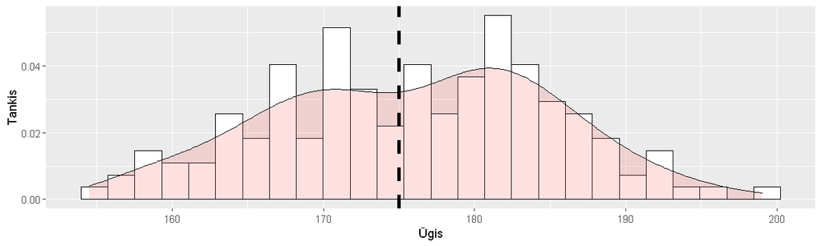

```r
ggplot(df, aes(x=ugis)) +
 geom_histogram(aes(y=..density..), colour="black",
                fill="white", bins=26) +
 geom_density(alpha=.2, fill="#FF6666") +
 geom_vline(xintercept = x_k, linetype="dashed",
                color = "black", size=1.5) +
  labs(y = 'Tankis',x = 'Ūgis',caption = waiver(),
       tag = waiver())
```

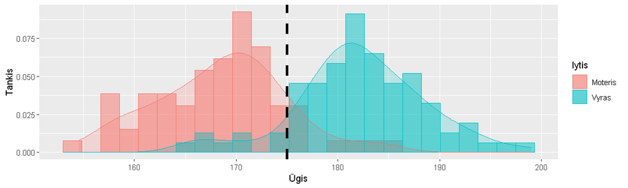

```r
plot.df = data.frame(lytis, ugis)
ggplot(plot.df, aes(x=ugis, color=lytis, fill=lytis)) +
 geom_histogram(aes(y=..density..), alpha=0.5,
                position="identity", bins=25) +
 geom_density(alpha=.2) +
 geom_vline(xintercept = x_k, linetype="dashed",
                color = "black", size=1.5) +
  labs(y = 'Tankis',x = 'Ūgis',caption = waiver(),
       tag = waiver())
```

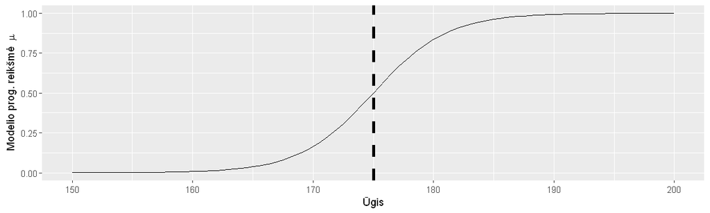

```r
plot.funkcija = p.ar_vyras
ggplot(data = data.frame(x = 0), mapping = aes(x = x)) +
  stat_function(fun = plot.funkcija) +
  xlim(150,200) +
  geom_vline(xintercept = x_k, linetype="dashed",
             color = "black", size=1.5) +
  labs(y = expression(paste('Modelio prog. reikšmė  ', mu)),
       x = 'Ūgis', caption = waiver(),tag = waiver())
```